# STAT 240 Discussion 5

## Group 311:1

## Members Present

Abigail Gandrud, Alexandra White, Akshay Joshi, **Zinnia Nie**

## Members Absent

N/A

## Questions

### 1

If $X \sim \text{N}(20, 3)$, what is $P(15 < X < 27)$?

```r
# insert code here
pnorm(27, 20, 3) - pnorm(15, 20, 3)
```

```
## [1] 0.9423943
```

$P(15 < X < 27)$ = **0.9423943**

### 2

Draw a graph of a normal distribution with mean 20 and standard deviation 3 with the area between 15 and 27 shaded. How does this area correspond to the previous calculated probability?

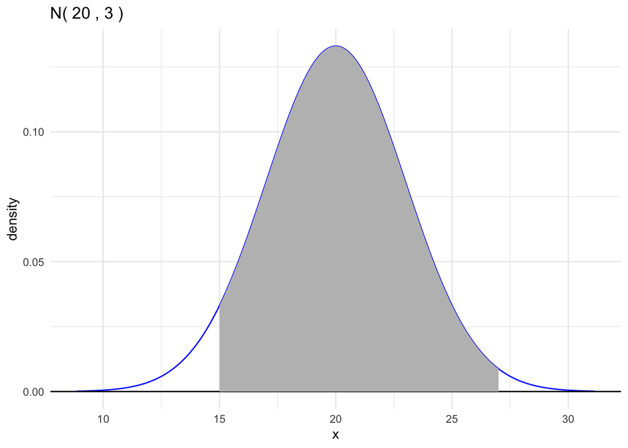

```r
gnorm(20, 3) +
  geom_norm_fill(20, 3, a=15, b=27, fill="gray") +
  theme_minimal()
```

> The shaded area is equal to the value of the probability we found in part 1.

### 3

Define $z_1 = (15 - 20)/3$ and $z_2 = (27 - 20)/3$. If $Z \sim \text{N}(0,1)$, what is $P(z_1 < Z < z_2)$?

```r
# insert code here
z1 = (15 - 20)/3
z2 = (27 - 20)/3
pnorm(z2) - pnorm(z1)
```

```
## [1] 0.9423943
```

$P(z_1 < Z < z_2)$ = **0.9423943**

### 4

Draw a graph of a standard normal distribution and shade the area under the curve between $z_1$ and $z_2$ from the previous problem. How does this plotted graph compare to the graph made in question 2?

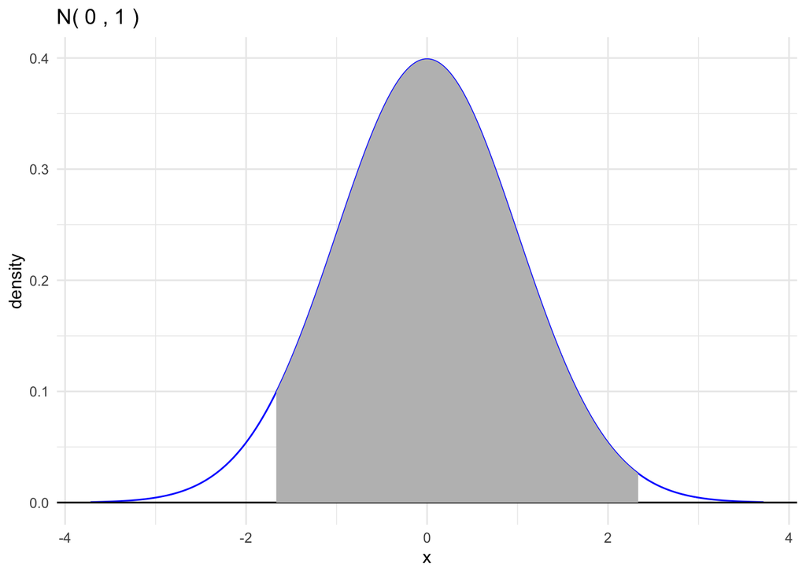

```r
# insert code here
gnorm(0, 1) +
  geom_norm_fill(0, 1, a=z1, b=z2, fill="gray") +
  theme_minimal()
```

> The graph looks the same visually, but the x axis has changed. The mean is at 0 not 20.

### 5

#### 5A

Using the chimpanzee data, combine all of the trials made without a partner. Count the number of pro-social and selfish choices made.

```r
# insert code here
chimpanzee = read_csv("../../data/chimpanzee-1.csv")

chimpanzee %>% filter(partner=="none") %>% summarise(total_social = sum(prosocial), total_selfish=sum(selfish))
```

```
## # A tibble: 1 × 2
##   total_social total_selfish
##          <dbl>         <dbl>
## 1           83            97
```

Number of pro-social choices: **83**

Number of selfish choices: **97**

#### 5B

Write a model for the number of pro-social choices.

> Variable: X is the number of pro-social choices subjects without a partner made in 180 trials

> Assume: each trial has 2 outcomes, pro-social or selfish, 180 trials is predetermined, trials are independent (this assumption is debatable), same probability of pro-social choice for each trial (this assumption is debatable)

> X has binomial distribution

> n = number of trials, n = 180

> p = unknown probability of pro-social choices

$X | p \sim \text{Binomial}(180,p)$ is the model

> Data is n = 180, x = 83

#### 5C

Use the Agresti-Coull method to construct a 95% confidence interval for the probability that a chimpanzee makes the pro-social choice in experimental conditions when there is no partner present.

```r
# insert code here
binom_se =  function(n, p)
{
  return ( sqrt( p*(1-p)/n) )
}

binom_ci = function(est, se, conf=0.95)
{
  z = qnorm(1 - (1 - conf)/2)
  me = z * se
  ci = est + c(-1,1)*me
  return(ci)
}

p_tilde = (83+2)/(180+4) # point estimate
p_tilde
```

```
## [1] 0.4619565
```

```r
se_agresti = binom_se(180+4, p_tilde)
se_agresti
```

```
## [1] 0.03675364
```

```r
ci_agresti = binom_ci(p_tilde, se_agresti)
round(ci_agresti, 3)
```

```
## [1] 0.390 0.534
```

> Confidence interval is $(0.390, 0.534)$.

#### 5D

Interpret this confidence interval in the context of the experimental setting.

> We are 95% confident that the proportion of the time a chimpanzee without a partner would make a pro-social choice will fall between 0.390 and 0.534.

### 6

Using the same data as in the previous problem, do the following.

#### 6A

State hypotheses for a two-sided hypothesis test that the probability that a chimpanzee makes the pro-social choice over the long run is equal to 0.5 versus the alternative that this probability is not 0.5.

> $H_0: X = 0.5$

> $H_a: X \ne 0.5$

#### 6B

Pick a test statistic, state the sampling distribution of this statistic if the null hypothesis is true, and compute a p-value for the test.

```r
# insert code here
pbinom(83, 180, 0.5) + (1 - pbinom(96, 180, 0.5))
```

```
## [1] 0.3325791
```

> The sampling distribution is binomial with $X \sim \text{Binomial}(180,0.5)$. The test statistic is $X=83$.

> The p value for the test is **0.3325791**.

#### 6C

Interpret these results in the context of the experiment following the examples from lecture notes.

> The p value is 0.3325791 which is greater than the significance level of 0.05. This means that there is not enough evidence to show that the probability that a chimpanzee without a partner will make a pro-social choice more or less than half the time in the long run under similar experimental conditions.

### 7

Use functions from the file `ggprob.R` to visualize the calculation of the p-value by graphing an appropriate probability distribution and using differential coloring to indicate what in the plot corresponds to the p-value. Include a title and meaningful axis labels.

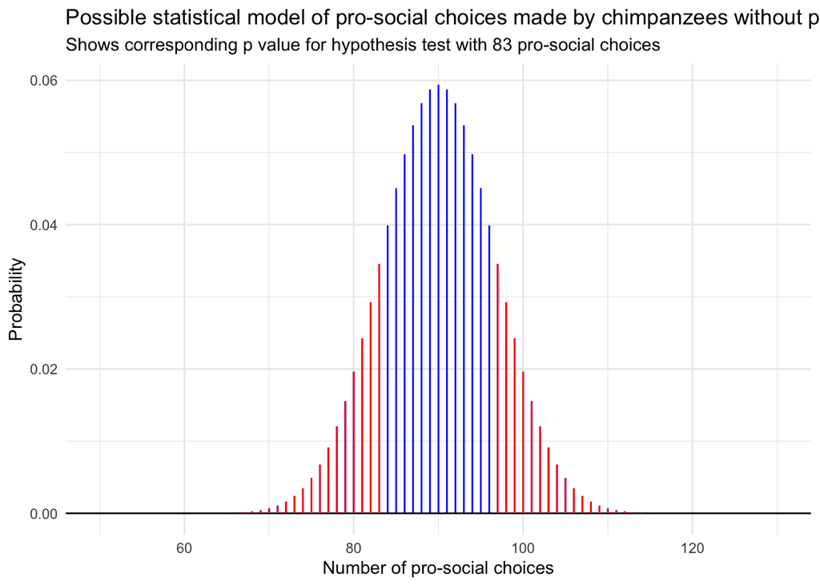

```r
# insert code here
gbinom(180, 0.5, scale=TRUE)  +
  geom_binom_density(180, 0.5, a=50, b=83, color="red") +
  geom_binom_density(180, 0.5, a=97, b=130, color="red") +
  theme_minimal() +
  xlab("Number of pro-social choices") +
  ggtitle("Possible statistical model of pro-social choices made by chimpanzees without partners", subtitle = "Shows corresponding p value for hypothesis test with 83 pro-social choices")
```